# Project_1

1.The independent variable is whether or not the words are congruent i.e the word condition (congruent vs. incongruent) and the dependent variable is the amount of time taken to perform the test (name the ink colors).

2.An appropriate null hypothesis is that the condition has no impact on the mean time required for the test, i.e. the mean time required by the population under the congruent condition is the same as the mean time required by the population under the incongruent condition. µ∆=µ2−µ1 H0:µ∆=0

In this case, the alternate hypothesis would be that the mean time taken under the two conditions is not the same.

We could do a dependent T-test on the difference in times between the two data conditions: congruent vs. incongruent. The T-test makes sense because we don't know any population statistics a priori, we only have our samples. Because the hypothesis does not state a direction, we will use a two-tailed test- we simply want to show that the condition has an impact on time required, regardless of whether it's slower or faster. HA:µ∆≠0

```
3. Following sections will show some desriptive Satistics
```

```python
#load the Data file for further examination
import pandas as pd
data = pd.read_csv('C:/Users/kallakuri/Documents/GitHub/P1-Test-a-Perceptual-Phenomenon/stroopdata.csv')

#Here are some descriptive statistics for the data set
data.describe()
```

|  | Congruent | Incongruent |
| --- | --- | --- |
| count | 24.000000 | 24.000000 |
| mean | 14.051125 | 22.015917 |
| std | 3.559358 | 4.797057 |
| min | 8.630000 | 15.687000 |
| 25% | 11.895250 | 18.716750 |
| 50% | 14.356500 | 21.017500 |
| 75% | 16.200750 | 24.051500 |
| max | 22.328000 | 35.255000 |

We can see that the mean time taken in the congruent condition is less than that in the incongruent condition and there is less variability in the congruent condition (i.e. the STD is lower). The open question now is whether the mean time in the congruent condition is significantly lower than the mean time in the incongruent condition

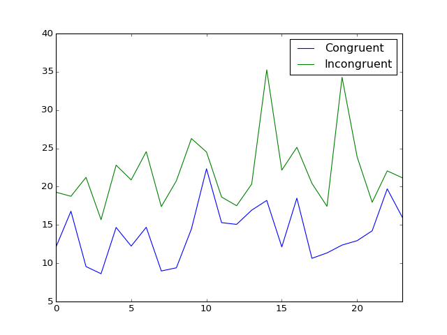

```python
%pylab notebook
data.plot()
```

[output not shown]

```python
Xc=data.Congruent.mean()
print('Mean of the time to read for the Congruent group: ', Xc)

Xinc=data.Incongruent.mean()
print('Mean of the time to read for the Incongruent group: ', Xinc)

Median_c=data.Congruent.median()
print('Median of the time to read for the Congruent group: ', Median_c)
Median_Inc=data.Incongruent.median()
print('Median of the time to read for the Incongruent group: ', Median_Inc)

Std_c=data.Congruent.std()
print('Standard deviation of the time to read for the Congruent group: ', Std_c)
Std_inc=data.Incongruent.std()
print('Standard deviation of the time to read for the Incongruent group: ', Std_inc)

print ("\n\nThe point estimate (Xc-Xinc) is:",Xc-Xinc)
```

```
Mean of the time to read for the Congruent group:  14.051125
Mean of the time to read for the Incongruent group:  22.0159166667
Median of the time to read for the Congruent group:  14.3565
Median of the time to read for the Incongruent group:  21.0175
Standard deviation of the time to read for the Congruent group:  3.55935795765
Standard deviation of the time to read for the Incongruent group:  4.79705712247


The point estimate (Xc-Xinc) is: -7.96479166667
```

```python
#Here we compute the standard deviation of the
#differences in time between the two conditions.
#Specifying ddof=1 causes a denominator of (n-1)
#to be used
S = difference.std(ddof=1)
print(S)
```

```
4.86482691036
```

So the t-statistic is:

```python
t_statistic=(Xc-Xinc)/(S/sqrt(len(data)))
print("The t_statistic is:",t_statistic)
```

```
The t_statistic is: -8.02070694411
```

t_critical_negative = - 2.069 t_critical_positive = 2.069 For alpha= 0.05 so 0.025 for each tail with 23 degree of freedom, t-critical = positive and negative 2.069. The t table can be find here[https://s3.amazonaws.com/udacity-hosted-downloads/t-table.jpg].

Let's compute the confidence interval:

```python
t_critical_negative = - 2.069
t_critical_positive =  2.069
lower_bound= (Xc-Xinc) + t_critical_negative*(S/sqrt(len(data)))
higher_bound= (Xc-Xinc) + t_critical_positive*(S/sqrt(len(data)))

print("Confidence interval:", "["+str(round(lower_bound,3))+","+ str(round(higher_bound,3))+"]")
```

```
Confidence interval: [-10.019,-5.91]
```

```
5. Because t-statistic < -t-critical it means that the t-statistic is in the the critical region so we should reject the null hypothesis.

So it means that the color of the ink in which the word is printed has an impact on the time it takes to read the list of word. The result match the expectations as we could anticipate that it takes more time to read the list when the names do not match the colors in which they are printed that may increase errors or confusion to read the list.
```

```
6. I suspect the delay observed in the incongruent condition is due to the cognitive interference caused by the Stroop task. Experiment participants are being asked to deal with two competing stimuli and resolving the conflict between the two requires thought and thus additional time.

Another task which might yield similar results would be flash cards with numbers printed on them of unequal size. In the congruent condition, the numerically larger value would also be printed physically larger, i.e. 7 is bigger than 2.

In the incongruent condition, the numerically smaller value is printed larger than the numerically larger value, i.e. 2 is bigger than 7. If a subject is then asked which number is "bigger" they might respond more slowly in the incongruent condition.
```